# Sentiment Analysis of *The Times* Music Reviews

## Part IV: Data Visualization of VADER Sentiment Analyzer Scores

*How have artforms been reported? Is there a status hierarchy between them? How has this changed over time?*

- **Project:** What counts as culture? Reporting and criticism in The Times 1785-2000
- **Project Team:** Dave O'Brien (lead), Lucy Havens (Jupyter Notebook author), Orian Brooke, Mark Taylor
- **Funding:** from the Centre for Data, Culture & Society, University of Edinburgh
- **Dataset:** 83,625 reviews about music published in The Times from 1950 through 2009 from The Times Archive

Begun February 2021

1. Load the Data
2. Analyze the Data

   2.1 Summary Statistics

### 1. Load the Data

First, import required programming libraries.

```python
# For data loading
import re
import string
import random
import math
import numpy as np
import pandas as pd

# For text analysis
import nltk
from nltk.tokenize import word_tokenize, sent_tokenize
# nltk.download('punkt')
from nltk.corpus import PlaintextCorpusReader
# nltk.download('wordnet')
from nltk.corpus import wordnet
# nltk.download('stopwords')
from nltk.corpus import stopwords
from nltk.text import Text
# nltk.download('averaged_perceptron_tagger')
# nltk.download('tagsets')  # part of speech tags
from nltk.tag import pos_tag

# For data visualization
import matplotlib.pyplot as plt
import seaborn as sns
```

Next, load the data from the VADER sentiment analyzer run on The Times reviews' text and load the inventory data.

We'll load these datasets into DataFrames, organizing the CSV file into rows and columns just as it was in the Sentiment Analysis Notebook (#2).

```python
dfs = pd.read_csv("../TheTimes_DaveO/TheTimesArticles_1950-2009_VADERSentiments.csv", index_col=0)
dfs.rename(columns={"article_id":"filepath"}, inplace=True)
dfs.head()
```

|  | filepath | compound | positive | neutral | negative |
| --- | --- | --- | --- | --- | --- |
| 0 | TheTimesMusicReviews_1950-2009_part1/20787 | 0.9897 | 0.075 | 0.912 | 0.013 |
| 1 | TheTimesMusicReviews_1950-2009_part1/20788 | 0.9978 | 0.230 | 0.744 | 0.025 |
| 2 | TheTimesMusicReviews_1950-2009_part1/20789 | 0.9912 | 0.124 | 0.866 | 0.010 |
| 3 | TheTimesMusicReviews_1950-2009_part1/20790 | 0.9886 | 0.133 | 0.822 | 0.044 |
| 4 | TheTimesMusicReviews_1950-2009_part1/20791 | 0.8225 | 0.061 | 0.893 | 0.046 |

```python
dfi = pd.read_csv("../TheTimes_DaveO/TheTimesArticles_1950-2009_Inventory.csv")
dfi.rename(columns={"Unnamed: 0":"identifier"}, inplace=True)
dfi.head()
```

|  | identifier | title | year | author | term | section | pages | filename | article_id | issue_id |
| --- | --- | --- | --- | --- | --- | --- | --- | --- | --- | --- |
| 0 | 20787 | SOME NEW SCORES MOTET AND OPERA | 1950 | BY OUR MUSIC CRITIC | [' bands', ' composer', ' musical', ' opera', ... | Reviews | [] | /lustre/home/dc125/shared/TDA_GDA_1785-2009/19... | 0FFO-1950-JUN30-008-023 | 0FFO-1950-JUN30 |
| 1 | 20788 | THE ROYAL OPERA " TRISTAN AND ISOLDE " | 1950 | '' | [' opera', ' orchestra'] | Reviews | [] | /lustre/home/dc125/shared/TDA_GDA_1785-2009/19... | 0FFO-1950-JUN30-008-027 | 0FFO-1950-JUN30 |
| 2 | 20789 | GROWING TASTE FOR MUSIC PLEA FOR ENLARGED QUEE... | 1950 | '' | [' country'] | Reviews | [] | /lustre/home/dc125/shared/TDA_GDA_1785-2009/19... | 0FFO-1950-JUN30-008-032 | 0FFO-1950-JUN30 |
| 3 | 20790 | ROYAL PHILHARMONIC CONCERT BEECHAM AND MOZART | 1950 | '' | [' orchestra', ' orchestras'] | Reviews | ['010'] | /lustre/home/dc125/shared/TDA_GDA_1785-2009/19... | 0FFO-1950-MAR02-010-006 | 0FFO-1950-MAR02 |
| 4 | 20791 | MUSICAL JOURNALS SOME NEWCOMERS | 1950 | BY OUR MUSIC CRITIC | [' musical', ' orchestra', ' orchestras'] | Reviews | ['007'] | /lustre/home/dc125/shared/TDA_GDA_1785-2009/19... | 0FFO-1950-MAR03-007-010 | 0FFO-1950-MAR03 |

Now we can merge these two DataFrames together using the `filepath` column from the first DataFrame and the `identifer` column from the second DataFrame.

```python
paths = list(dfs.filepath)
ids = []
for p in paths:
    ids += [int((re.findall("\d{1,}$",p))[0])]

print(ids[:10]) # print the first 10 ids
```

```
[20787, 20788, 20789, 20790, 20791, 20792, 20793, 20794, 20795, 20796]
```

Add an `identifier` column to the first DataFrame of sentiment analysis results.

```python
dfs["identifier"] = ids
dfs.head(3)
```

|  | filepath | compound | positive | neutral | negative | identifier |
| --- | --- | --- | --- | --- | --- | --- |
| 0 | TheTimesMusicReviews_1950-2009_part1/20787 | 0.9897 | 0.075 | 0.912 | 0.013 | 20787 |
| 1 | TheTimesMusicReviews_1950-2009_part1/20788 | 0.9978 | 0.230 | 0.744 | 0.025 | 20788 |
| 2 | TheTimesMusicReviews_1950-2009_part1/20789 | 0.9912 | 0.124 | 0.866 | 0.010 | 20789 |

Now we can join the DataFrames on their `identifier` columns!

```python
df = dfi.merge(dfs, how="outer", on="identifier")
df.head(3)
```

|  | identifier | title | year | author | term | section | pages | filename | article_id | issue_id | filepath | compound | positive | neutral | negative |
| --- | --- | --- | --- | --- | --- | --- | --- | --- | --- | --- | --- | --- | --- | --- | --- |
| 0 | 20787 | SOME NEW SCORES MOTET AND OPERA | 1950 | BY OUR MUSIC CRITIC | [' bands', ' composer', ' musical', ' opera', ... | Reviews | [] | /lustre/home/dc125/shared/TDA_GDA_1785-2009/19... | 0FFO-1950-JUN30-008-023 | 0FFO-1950-JUN30 | TheTimesMusicReviews_1950-2009_part1/20787 | 0.9897 | 0.075 | 0.912 | 0.013 |
| 1 | 20788 | THE ROYAL OPERA " TRISTAN AND ISOLDE " | 1950 | '' | [' opera', ' orchestra'] | Reviews | [] | /lustre/home/dc125/shared/TDA_GDA_1785-2009/19... | 0FFO-1950-JUN30-008-027 | 0FFO-1950-JUN30 | TheTimesMusicReviews_1950-2009_part1/20788 | 0.9978 | 0.230 | 0.744 | 0.025 |
| 2 | 20789 | GROWING TASTE FOR MUSIC PLEA FOR ENLARGED QUEE... | 1950 | '' | [' country'] | Reviews | [] | /lustre/home/dc125/shared/TDA_GDA_1785-2009/19... | 0FFO-1950-JUN30-008-032 | 0FFO-1950-JUN30 | TheTimesMusicReviews_1950-2009_part1/20789 | 0.9912 | 0.124 | 0.866 | 0.010 |

```python
# Check for null values
print(df.year.isnull().values.any())
print(df.term.isnull().values.any())
print(df.title.isnull().values.any())
print(df.section.isnull().values.any())
print(df.pages.isnull().values.any())
```

```
False
False
False
False
False
```

Great, it looks like we haven't lost any articles' metadata! All the reviews' years, terms, titles, sections, and pages have a value.

Now that we have the reviews' sentiment data joined up with the reviews' metadata, we can export the data as a CSV file for quicker reference in the future.

```python
df.to_csv("../TheTimes_DaveO/TheTimesArticles_1950-2009_MetadataWithVADERSentiments.csv")
```

## 2. Analyze the Data

### 2.1 Summary Statistics

Let's figure out what the most positive, negative, and neutral reviews are and what scores the VADER Sentiment Analyzer assigned them.

```python
# Load a DataFrame of reviews and their sentiment scores if section 1 skipped
# (uncomment the code below by removing the '#' at the beginning of the line, and press shift+enter to run)
#df = pd.read_csv("../TheTimes_DaveO/TheTimesArticles_1950-2009_MetadataWithVADERSentiments.csv")
```

```python
maxPos = max(df.positive)
print("Highest Positive Score:\n\t", maxPos)
print("Review with Highest Positive Score:\n\t", list(df.title[df.positive == maxPos])[0], "(Identifier:",list(df.identifier[df.positive == maxPos])[0], ")")
```

```
Highest Positive Score:
	 0.457
Review with Highest Positive Score:
	 \  \"The Feigned Lady Gardener\" doesnt exactly trip off the tongue , but\ (Identifier: 72571 )
```

```python
maxNeg = max(df.negative)
print("Highest Negative Score:\n\t", maxNeg)
print("Review with Highest Negative Score:\n\t", list(df.title[df.negative == maxNeg])[0], "(Identifier:",list(df.identifier[df.negative == maxNeg])[0], ")")
```

```
Highest Negative Score:
	 0.319
Review with Highest Negative Score:
	 The Art of Noise The1 week's best music video (Identifier: 98832 )
```

```python
maxNeu = max(df.neutral)
print("Highest Neutral Score:\n\t", maxNeu)
print("Review with Highest Neutral Score:\n\t", list(df.title[df.neutral == maxNeu])[0], "(Identifier:",list(df.identifier[df.neutral == maxNeu])[0], ")")
```

```
Highest Neutral Score:
	 1.0
Review with Highest Neutral Score:
	 BRITISH MUSIC SUNG AT ST. JOHN LATFRAN A CONTEMPORARY MASS (Identifier: 21217 )
```

```python
maxCom = max(df["compound"])
minCom = min(df["compound"])
print("Most Positive (Highest) Compound Score:\n\t", maxCom)
print("Review with Most Positive (Highest) Compount Score:\n\t", list(df.title[df["compound"] == maxCom])[0], "(Identifier:",list(df.identifier[df["compound"] == maxCom])[0], ")")
print("\nMost Negative (Lowest) Compound Score:\n\t", minCom)
print("Review with Most Negative (Lowest) Compount Score:\n\t", list(df.title[df["compound"] == minCom])[0], "(Identifier:",list(df.identifier[df["compound"] == minCom])[0], ")")
```

```
Most Positive (Highest) Compound Score:
	 1.0
Review with Most Positive (Highest) Compount Score:
	 . . .. . " i / . . k LUCGIRAHD (Identifier: 64287 )

Most Negative (Lowest) Compound Score:
	 -0.9998
Review with Most Negative (Lowest) Compount Score:
	 '1993: the year a simple handshake gave new hope lor a more peaceful world...' (Identifier: 70658 )
```

### 2.2 Analysis by Genre

The *defoe* text mining output reports the music-related terms that each review contains, so we can create subsets of our data based on the these terms.

```python
# From https://github.com/defoe-code/defoe/blob/master/queries/music_genres.txt
genres = ['music', 'african', 'big band', 'bluegrass', 'country', 'blues', 'musical', 'classical',
          'electronic', 'folk', 'gospel', 'hip hop', 'jazz', 'latin', 'metal', 'easy listening',
          'opera', 'pop', 'rap', 'rave', 'reggae', 'rock']

musical_terms = ["song", "lyric", "album", "band", "artist", "singer", "songwriter", "rapper", "composer",
                 "composition", "orchesra", "dj", "music"]
```

#### 2.2.1 Analysis by Genre: OPERA

Let's start with an analysis of reviews that use the term **opera**.

**Step 1:** Identify which articles have the term "opera."

```python
def termFilter(term_string, dataframe):
    df_terms = list(dataframe.term)
    with_term = []
    for t in df_terms:
        if term_string in t:
            with_term += [True]
        else:
            with_term += [False]

    assert(len(with_term) == len(df_terms))
    return with_term

with_opera = termFilter(" opera", df)
```

**Step 2:** Create a subset of the data that ONLY includes articles with the term "opera."

```python
df["with_opera"] = with_opera
df_opera = df[df["with_opera"] == True]
print(df_opera.shape)
```

```
(18628, 16)
```

```python
df_opera.tail()
```

|  | identifier | title | year | author | term | section | pages | filename | article_id | issue_id | filepath | compound | positive | neutral | negative | with_opera |
| --- | --- | --- | --- | --- | --- | --- | --- | --- | --- | --- | --- | --- | --- | --- | --- | --- |
| 83606 | 106791 | John Scrimger, Linda Ormiston, Marilyn HIII Smith | 2009 | '' | [' musical', ' opera'] | Reviews | [] | /lustre/home/dc125/shared/TDA_GDA_1785-2009/19... | 0FFO-2009-0815-0268-006 | 0FFO-2009-0815 | TheTimesMusicReviews_1950-2009_part2/106791 | 0.4939 | 0.084 | 0.916 | 0.000 | True |
| 83609 | 106794 | '' | 2009 | '' | [' classical', ' jazz', ' opera'] | Reviews | [] | /lustre/home/dc125/shared/TDA_GDA_1785-2009/19... | 0FFO-2009-0815-0268-017 | 0FFO-2009-0815 | TheTimesMusicReviews_1950-2009_part2/106794 | 0.9812 | 0.162 | 0.802 | 0.036 | True |
| 83610 | 106795 | Which shows? | 2009 | '' | [' musical', ' opera', ' rock'] | Reviews | ['0271'] | /lustre/home/dc125/shared/TDA_GDA_1785-2009/19... | 0FFO-2009-0815-0271-002 | 0FFO-2009-0815 | TheTimesMusicReviews_1950-2009_part2/106795 | -0.9401 | 0.000 | 0.736 | 0.264 | True |
| 83616 | 106801 | Desolate islands' ghostly power | 2009 | Richard Morrison | [' band', ' electronic', ' opera', ' singers',... | Reviews | [] | /lustre/home/dc125/shared/TDA_GDA_1785-2009/19... | 0FFO-2009-0817-0080-003 | 0FFO-2009-0817 | TheTimesMusicReviews_1950-2009_part2/106801 | 0.9452 | 0.100 | 0.840 | 0.060 | True |
| 83619 | 106804 | "Prom 39 BBCSO/Brabbins Albert Hall/Radio 3 w ... | 2009 | Hilary Finch | [' electronic', ' musical', ' opera', ' orches... | Reviews | [] | /lustre/home/dc125/shared/TDA_GDA_1785-2009/19... | 0FFO-2009-0817-0081-001 | 0FFO-2009-0817 | TheTimesMusicReviews_1950-2009_part2/106804 | 0.9849 | 0.142 | 0.805 | 0.053 | True |

**Step 3:** Calculate the maximum, minimum, and average compound sentiment scores.

```python
print("Most positive opera review:", max(df_opera["compound"]))
print("Most negative opera review:", min(df_opera["compound"]))
print("Average opera review compound score:", np.mean(df_opera["compound"]))
```

```
Most positive opera review: 1.0
Most negative opera review: -0.9998
Average opera review compound score: 0.8428176562164506
```

It looks like most of the reviews with the word "opera" are pretty positive! Let's create a visualization of the data so we can get a better sense of the opera data overall.

**Step 4:** Graph the yearly average scores of reviews with the word "opera."

```python
# Create a DataFrame with the compound, positive, and negative scores for a given genre
def makeScoreDataFrame(df_genre):
    df_scores = pd.DataFrame({"identifier":list(df_genre["identifier"]), "compound":list(df_genre["compound"]),
                        "positive":list(df_genre["positive"]), "neutral":list(df_genre["neutral"]),
                        "negative":list(df_genre["negative"]), "year":list(df_genre["year"])})
    df_scores.set_index("identifier", inplace=True)
    return df_scores
```

```python
opera_vader = makeScoreDataFrame(df_opera)

# Write the VADER sentiment score data to a CSV for quick reference in the future
opera_vader.to_csv("SentimentCharts/vader_data_opera.csv")

opera_yearly = opera_vader.groupby(by="year").mean().reset_index()
opera_yearly.tail()
```

|  | year | compound | positive | neutral | negative |
| --- | --- | --- | --- | --- | --- |
| 55 | 2005 | 0.812485 | 0.113045 | 0.834313 | 0.052647 |
| 56 | 2006 | 0.664850 | 0.107682 | 0.833697 | 0.058611 |
| 57 | 2007 | 0.533270 | 0.110242 | 0.821447 | 0.068330 |
| 58 | 2008 | 0.385795 | 0.104160 | 0.820360 | 0.075440 |
| 59 | 2009 | 0.692013 | 0.115810 | 0.826000 | 0.058168 |

```python
# Print the smallest and largest values for the compound VADER score
print(min(opera_yearly["compound"]))
print(max(opera_yearly["compound"]))
```

```
0.3857946666666665
0.9514906137184123
```

```python
# Reorganize the DataFrame so we can visualize each category of score (compound, positive, neutral, and negative)
opera_yearly_melted = opera_yearly.melt(id_vars=["year"], value_vars=["compound", "positive", "neutral", "negative"])
opera_yearly_melted.rename(columns={"variable":"VADER category", "value":"score"}, inplace=True)
opera_yearly_melted.tail()
```

|  | year | VADER category | score |
| --- | --- | --- | --- |
| 235 | 2005 | negative | 0.052647 |
| 236 | 2006 | negative | 0.058611 |
| 237 | 2007 | negative | 0.068330 |
| 238 | 2008 | negative | 0.075440 |
| 239 | 2009 | negative | 0.058168 |

Let's define which colors we'd like our visualizations to use for each type of VADER sentiment score:

```python
color_dict = dict({'compound':'dodgerblue', 'negative':'red', 'positive':'green', 'neutral':'orange'})
```

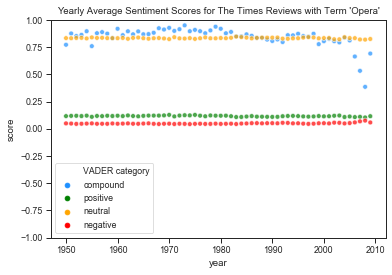

```python
opera_viz = sns.scatterplot(data=opera_yearly_melted, x="year", y="score", hue="VADER category", palette=color_dict, alpha=.7)
opera_viz.set(ylim=(-1,1),title="Yearly Average Sentiment Scores for The Times Reviews with Term 'Opera'")
plt.show()
opera_viz.figure.savefig("yearly_vader_averages_opera.png")
```

```python
opera_melted = opera_vader.melt(id_vars=["year"], value_vars=["compound", "positive", "neutral", "negative"])
opera_melted.rename(columns={"variable":"VADER category", "value":"score"}, inplace=True)
#opera_melted.head()
```

```python
# # Add a 'decade' column to the DataFrame
# def addDecadeColumn(df):
#     decades = []
#     years = list(df.year)
#     for y in years:
#         d = (math.floor((y)/10))*10
#         decades += [str(d)+"s"]
#     df["decade"] = decades
#     return df

# opera_decades = addDecadeColumn(opera_melted)
# #opera_decades.head()
# g = sns.FacetGrid(opera_decades, col="decade", hue="VADER category", palette=color_dict, col_wrap=3, aspect=2)
# g.map(sns.scatterplot, "year", "score", alpha=.7)
# g.add_legend()
```

```python
# Create one DataFrame per decade of data
# We'll do this for four genres, so let's write a function to avoid re-writing code!
def plotScoresByDecade(vader, genre):
    vader_1950s = vader[(vader.year < 1960)]
    vader_1960s = vader[(vader["year"] >= 1960) & (vader["year"] < 1970)]
    vader_1970s = vader[(vader["year"] >= 1970) & (vader["year"] < 1980)]
    vader_1980s = vader[(vader["year"] >= 1980) & (vader["year"] < 1990)]
    vader_1990s = vader[(vader["year"] >= 1990) & (vader["year"] < 2000)]
    vader_2000s = vader[(vader["year"] >= 2000)]
    scores = ["compound", "positive", "neutral", "negative"]
    for score in scores:
        sns.set_context("paper")
        fig, ax = plt.subplots(2,3, sharex=False, sharey=False, figsize=(16,10))
        fig.suptitle("VADER "+str(score.capitalize())+" Scores of The Times Reviews with Term '"+genre.capitalize()+"' by Decade", fontsize=14)
        fig.tight_layout(pad=5)
        if score == "compound":
            y_min, y_max = -1, 1
        else:
            y_min, y_max = 0, 1
        sns.scatterplot(ax=ax[0,0], x=vader_1950s["year"], y=vader_1950s[score], color=color_dict[score], alpha=.7)
        ax[0,0].set(title=score.capitalize()+" Scores in 1950s", xlim=(1949,1960), ylim=(y_min, y_max))
        sns.scatterplot(ax=ax[0,1], x=vader_1960s["year"], y=vader_1960s[score], color=color_dict[score], alpha=.7)
        ax[0,1].set(title=score.capitalize()+" Scores in 1960s", xlim=(1959,1970), ylim=(y_min, y_max))
        sns.scatterplot(ax=ax[0,2], x=vader_1970s["year"], y=vader_1970s[score], color=color_dict[score], alpha=.7)
        ax[0,2].set(title=score.capitalize()+" Scores in 1970s", xlim=(1969,1980), ylim=(y_min, y_max))
        sns.scatterplot(ax=ax[1,0], x=vader_1980s["year"], y=vader_1980s[score], color=color_dict[score], alpha=.7)
        ax[1,0].set(title=score.capitalize()+" Scores in 1980s", xlim=(1979,1990), ylim=(y_min, y_max))
        sns.scatterplot(ax=ax[1,1], x=vader_1990s["year"], y=vader_1990s[score], color=color_dict[score], alpha=.7)
        ax[1,1].set(title=score.capitalize()+" Scores in 1990s", xlim=(1989,2000), ylim=(y_min, y_max))
        sns.scatterplot(ax=ax[1,2], x=vader_2000s["year"], y=vader_2000s[score], color=color_dict[score], alpha=.7)
        ax[1,2].set(title=score.capitalize()+" Scores in 2000s", xlim=(1999,2010), ylim=(y_min, y_max))

        sns.set_style("ticks")
        sns.despine(left=True, trim=False)
        plt.show()

        fig.savefig("SentimentCharts/vader_"+score+"_by_decade_"+genre+".png")
```

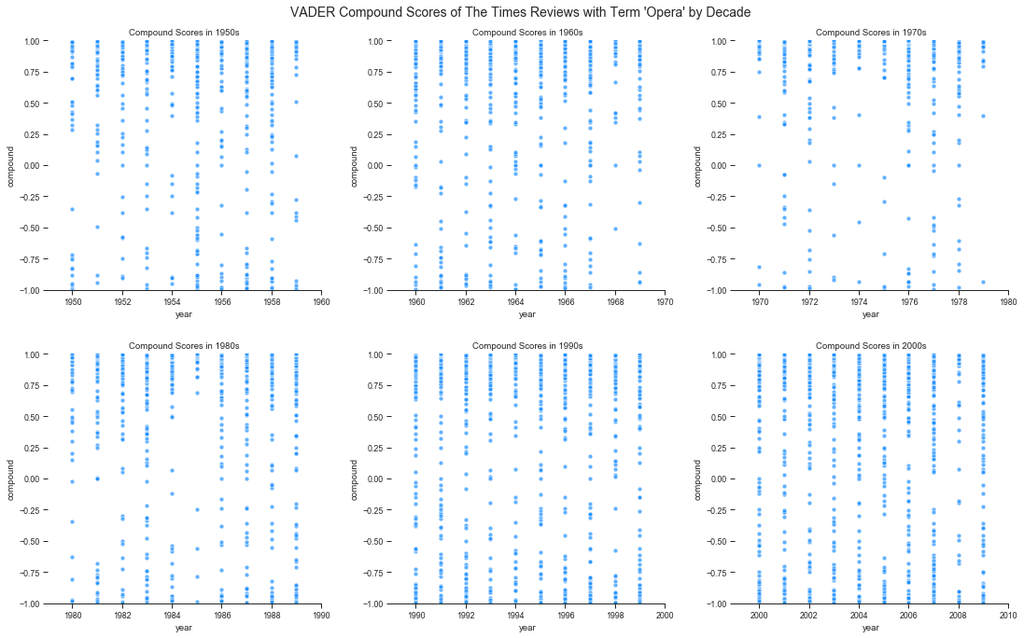

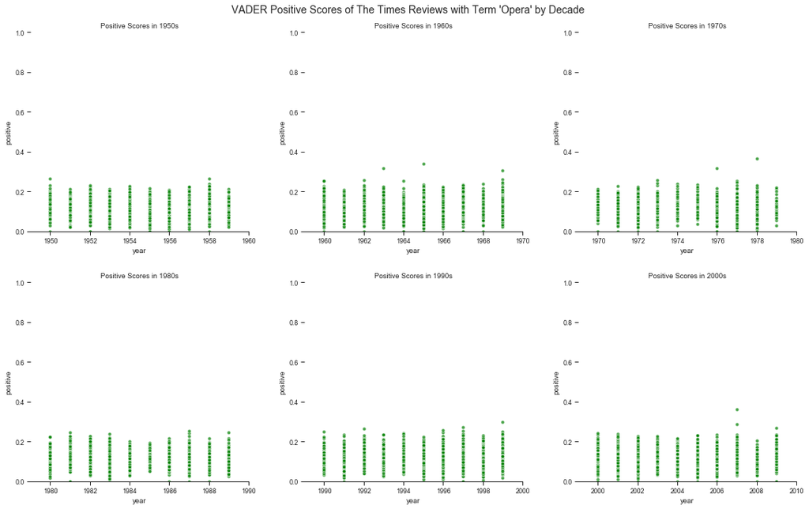

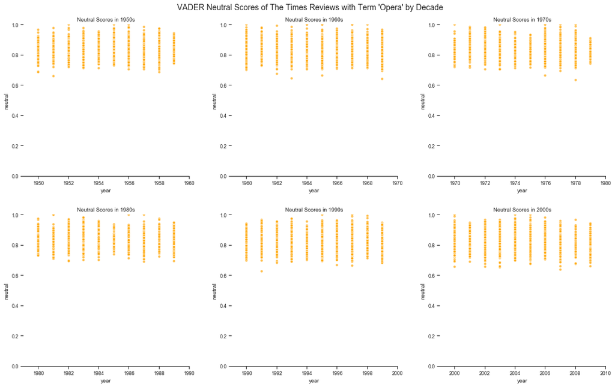

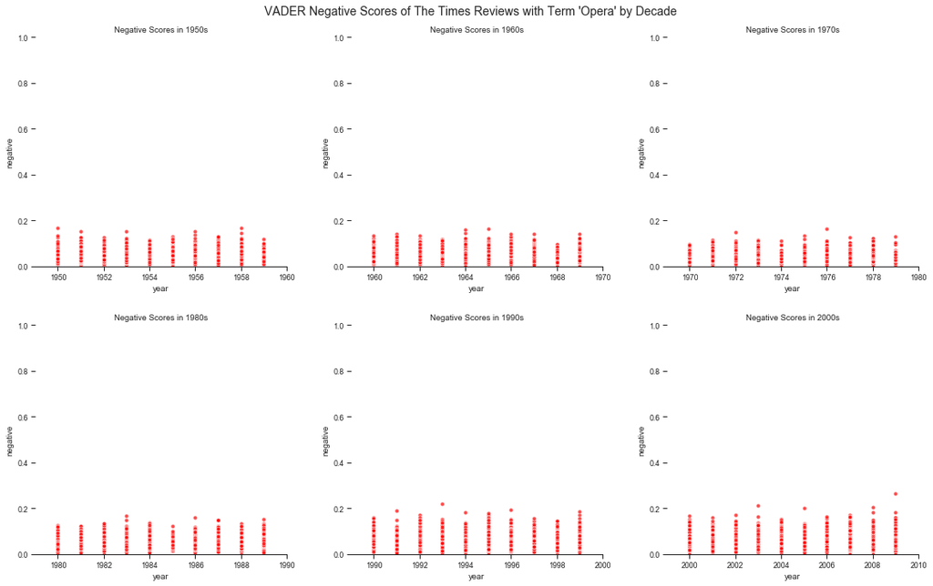

```python
plotScoresByDecade(opera_vader, "opera")
```

#### 2.2.2 Analysis by Genre: ROCK

Let's start with an analysis of reviews that use the term **rock**.

**Step 1:** Identify which articles have the term "rock."

```python
with_rock = termFilter(" rock", df)
df["with_rock"] = with_rock
df_rock = df[df["with_rock"] == True]
print(df_rock.shape)
# df_rock.head()
```

```
(9222, 17)
```

```python
print("Most positive rock review:", max(df_rock["compound"]))
print("Most negative rock review:", min(df_rock["compound"]))
print("Average rock review compound score:", np.mean(df_rock["compound"]))
```

```
Most positive rock review: 1.0
Most negative rock review: -0.9998
Average rock review compound score: 0.7506756126653603
```

On average, the reviews with the term "rock" have a slightly less positive score than reviews with the term "opera."

**Step 2:** Visualize the yearly average VADER compound score for The Times' reviews with the term 'rock.'

[output not shown]

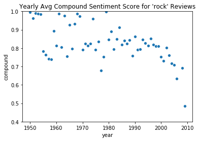

```python
rock_viz = sns.scatterplot(data=rock_yearly, x="year", y="compound")
rock_viz.set(ylim=(0.4, 1), title="Yearly Avg Compound Sentiment Score for 'rock' Reviews")  # use the same y range as the opera visualization
rock_viz.figure.savefig("yearly_compound_rock.png")
```

This looks quite different from the "opera" visualization! The sentiment fluctuates more from year to year and overall doesn't go drop as low as opera does. Since 1980, both have a downward trend, moving towards less positive sentiment (though not reaching what the VADER documentation classifies as negative sentiment).

**Step 3:** Visualize all VADER's scores for reviews with the term 'rock' by decade (as we did for the term 'opera').

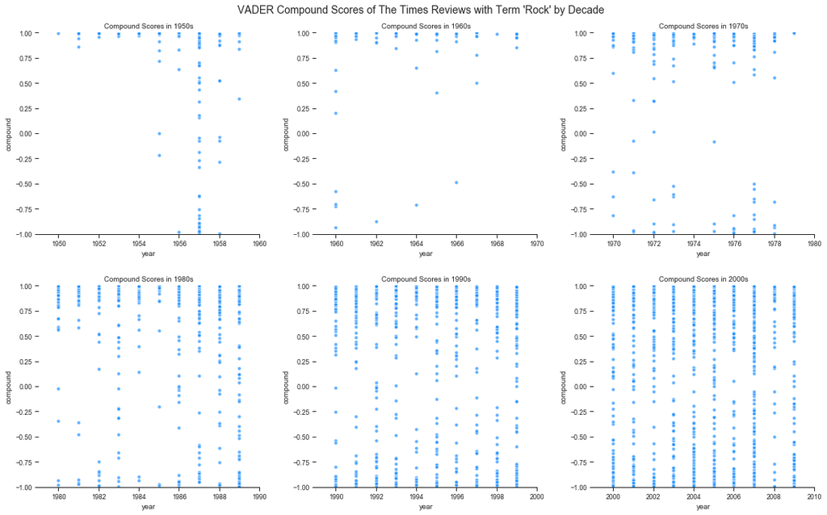

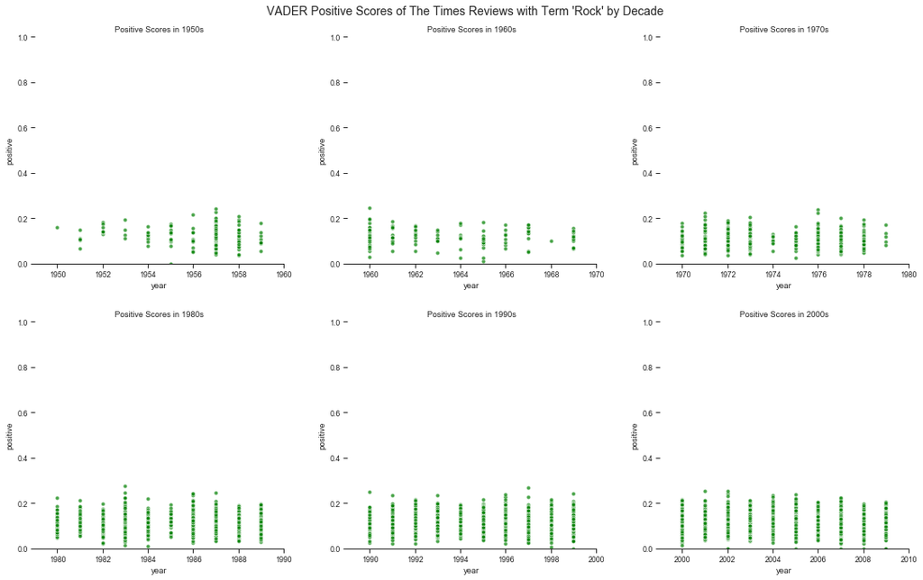

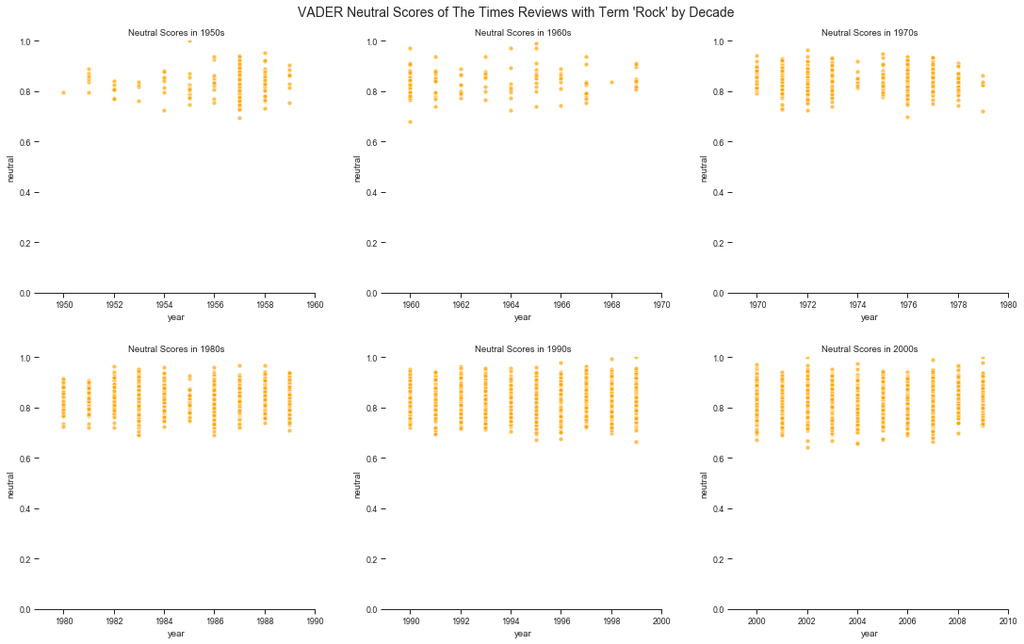

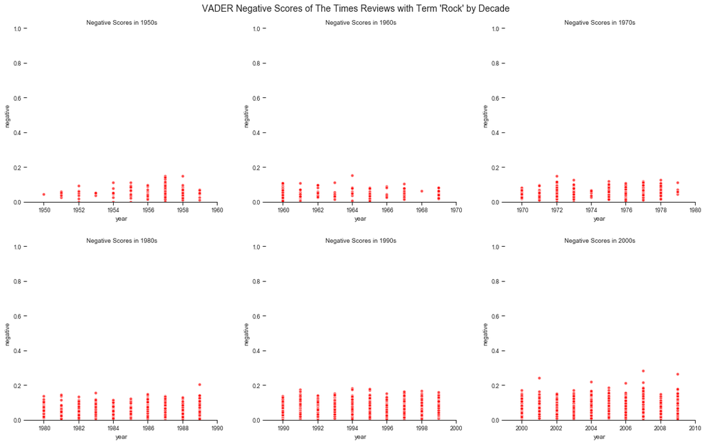

```python
rock_vader = makeScoreDataFrame(df_rock)
# Save the score data for quick reference in the future
rock_vader.to_csv("SentimentCharts/vader_data_rock.csv")
# Create one DataFrame per decade of data
plotScoresByDecade(rock_vader, "rock")
```

#### 2.2.3 Analysis by Genre: RAP

**Step 1:** Create a subset of data with The Times reviews that contain the term 'rap.'

```python
with_rock = termFilter(" rap", df)
df["with_rap"] = with_rock
df_rap = df[df["with_rap"] == True]
print(df_rap.shape)
print("Most positive rap review:", max(df_rap["compound"]))
print("Most negative rap review:", min(df_rap["compound"]))
print("Average rap review compound score:", np.mean(df_rap["compound"]))
rap_compound = pd.DataFrame({"compound":list(df_rap["compound"]), "year":list(df_rap["year"])})
rap_yearly = rap_compound.groupby(by="year").mean().reset_index()
min(rap_yearly["compound"])
```

```
(1925, 18)
Most positive rap review: 0.9999
Most negative rap review: -0.9998
Average rap review compound score: 0.7471128311688315
```

```
-0.6756
```

**Step 2:** Visualize the yearly average VADER compound score for The Times' reviews with the term 'rap.'

[output not shown]

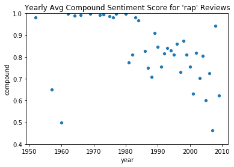

```python
rap_viz = sns.scatterplot(data=rap_yearly, x="year", y="compound")
rap_viz.set(ylim=(0.4, 1), title="Yearly Avg Compound Sentiment Score for 'rap' Reviews")  # use the same y range as the opera visualization
rap_viz.figure.savefig("yearly_compound_rap.png")
```

Again a very different visualization!

**Step 3:** Visualize all VADER scores for every review with the term 'rap' by decade (as with opera and rock).

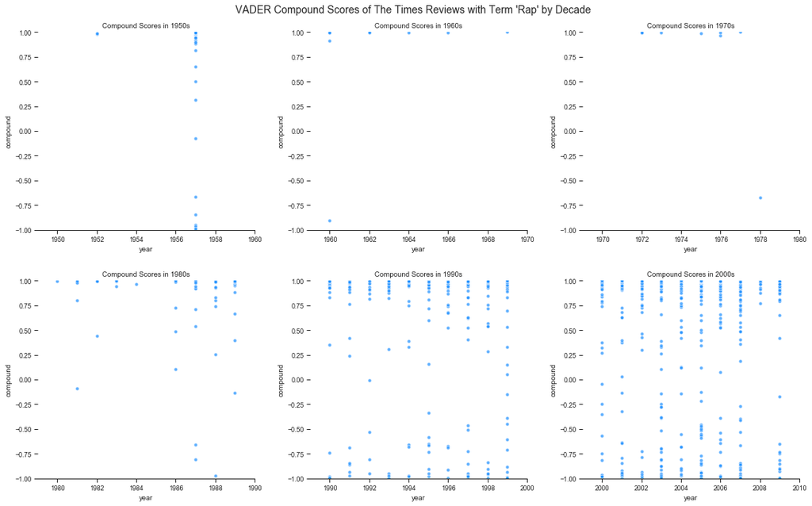

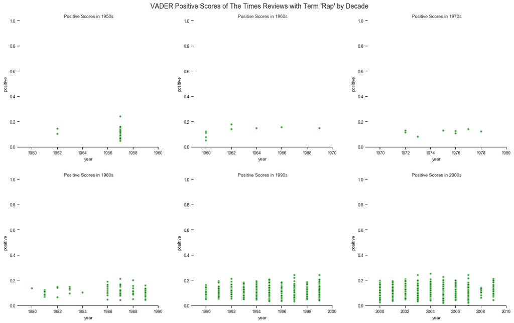

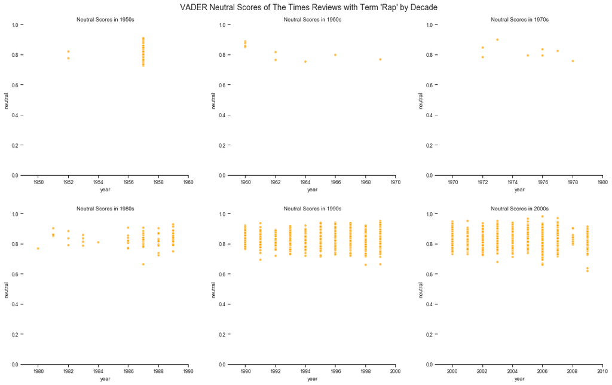

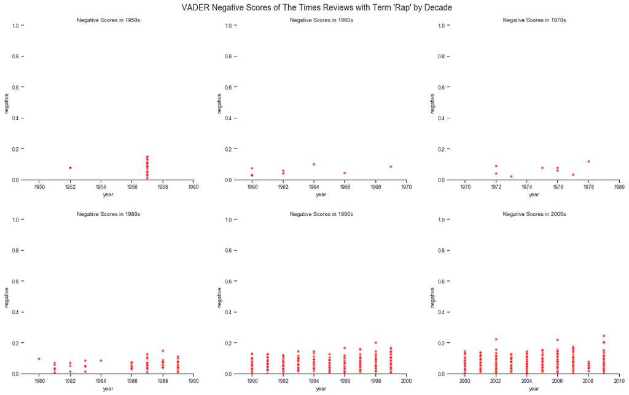

```python
rap_vader = makeScoreDataFrame(df_rap)
rap_vader.to_csv("SentimentCharts/vader_data_rap.csv")
# Create one DataFrame per decade of data
plotScoresByDecade(rap_vader, "rap")
```

#### 2.2.4 Analysis by Genre: JAZZ

**Step 1:** Create a subset of data with reviews from The Times that have the term 'jazz.'

```python
with_jazz = termFilter(" jazz", df)
df["with_jazz"] = with_jazz
df_jazz = df[df["with_jazz"] == True]
print(df_jazz.shape)
print("Most positive jazz review:", max(df_jazz["compound"]))
print("Most negative jazz review:", min(df_jazz["compound"]))
print("Average jazz review compound score:", np.mean(df_jazz["compound"]))
jazz_compound = pd.DataFrame({"compound":list(df_jazz["compound"]), "year":list(df_jazz["year"])})
jazz_yearly = jazz_compound.groupby(by="year").mean().reset_index()
min(jazz_yearly["compound"])
```

```
(7681, 19)
Most positive jazz review: 1.0
Most negative jazz review: -0.9997
Average jazz review compound score: 0.8412799765655452
```

```
0.57526
```

**Step 2:** Visualize the yearly average VADER compound score for The Times' reviews with the term 'jazz.'

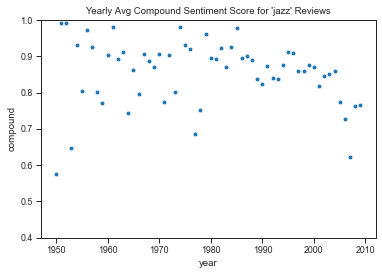

```python
jazz_viz = sns.scatterplot(data=jazz_yearly, x="year", y="compound")
jazz_viz.set(ylim=(0.4, 1), title="Yearly Avg Compound Sentiment Score for 'jazz' Reviews")  # use the same y range as the opera visualization
jazz_viz.figure.savefig("SentimentCharts/yearly_compound_jazz.png")
```

Yet again, a different visualization!

**Step 3:** Visualize all VADER scores for every review with the term 'jazz' by decade (as with opera, rock, and rap).

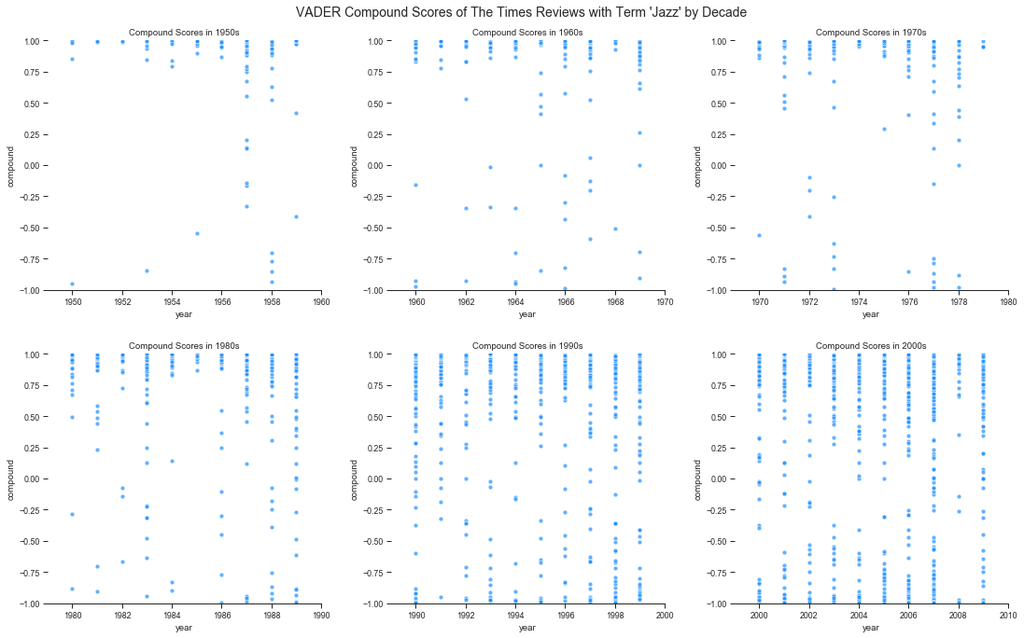

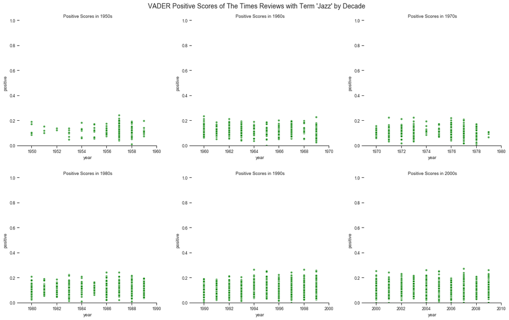

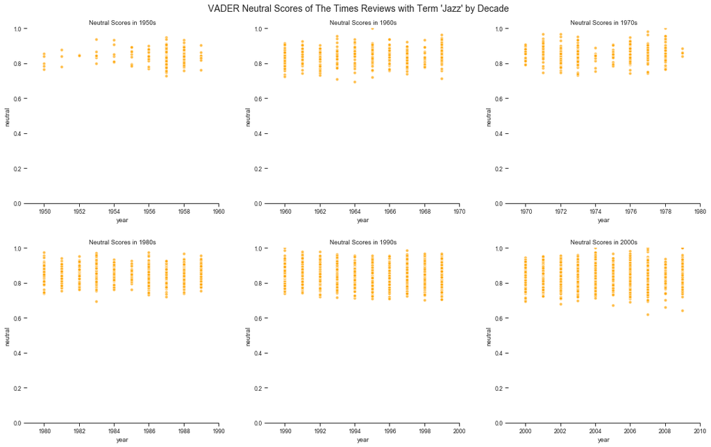

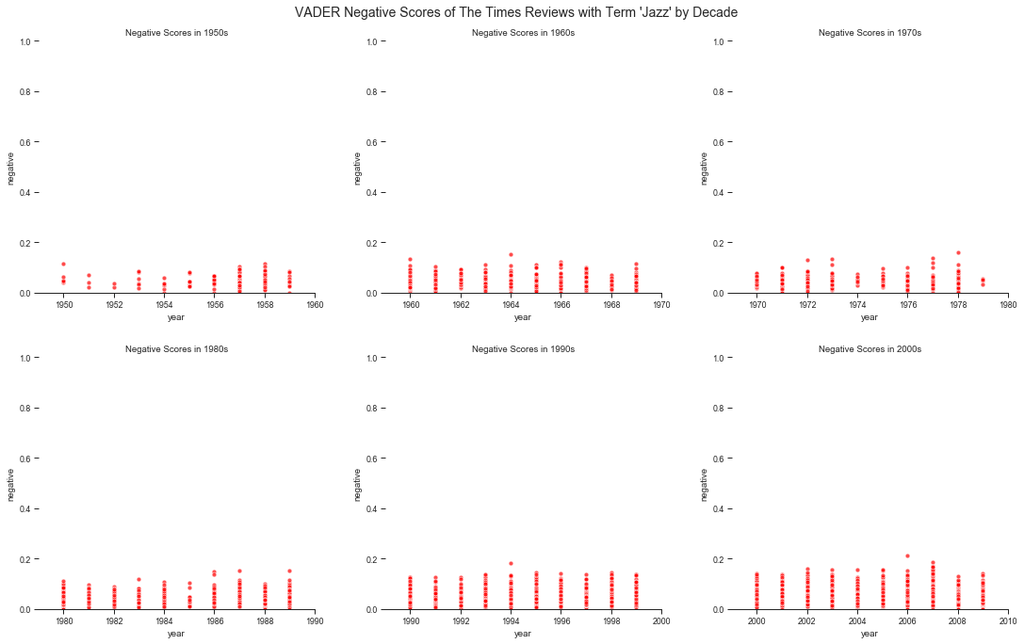

```python
jazz_vader = makeScoreDataFrame(df_jazz)
jazz_vader.to_csv("SentimentCharts/vader_data_jazz.csv")
# Create one DataFrame per decade of data
plotScoresByDecade(jazz_vader, "jazz")
```